# Exercise 4 – Classification II

[Introduction to Machine Learning](https://slds-lmu.github.io/i2ml/)

## Exercise 1: Naive Bayes

**Learning goals**

You are given the following table with the target variable `Banana`:

| ID | Color | Form | Origin | Banana |
| --- | --- | --- | --- | --- |
| 1 | yellow | oblong | imported | yes |
| 2 | yellow | round | domestic | no |
| 3 | yellow | oblong | imported | no |
| 4 | brown | oblong | imported | yes |
| 5 | brown | round | domestic | no |
| 6 | green | round | imported | yes |
| 7 | green | oblong | domestic | no |
| 8 | red | round | imported | no |

We want to use a Naive Bayes classifier to predict whether a new fruit is a `Banana` or not. Estimate the posterior probability $\hat\pi(\mathbf{x}_{\ast})$ for a new observation $\mathbf{x}_{\ast} = (\text{yellow}, \text{round}, \text{imported})$. How would you classify the object?

**Solution**

When using the naive Bayes classifier, the features $\mathbf{x}:= (x_\text{Color},x_\text{Form},x_\text{Origin})$ are assumed to be conditionally independent of each other, given the category $y = k \in \{\text{yes}, \text{no}\}$, s.t.

$$\mathbb{P}(\mathbf{x}~|~ y = k) =
\mathbb{P}((x_\text{Color}, x_\text{Form}, x_\text{Origin}) ~|~ y = k) =
\mathbb{P}(x_\text{Color} ~|~ y = k) \cdot \mathbb{P}(x_\text{Form} ~|~ y = k) \cdot
\mathbb{P}(x_\text{Origin} ~|~ y = k).$$

Recall Bayes’ theorem:

$$\pi_{k}(\mathbf{x})= \mathbb{P}(y = k ~|~ \mathbf{x})= \frac{\mathbb{P}(\mathbf{x}| y= k) \mathbb{P}(y= k)}{\mathbb{P}(\mathbf{x})}$$

As the denominator is constant across all classes, the following holds for the posterior probabilities:

$$\pi_{k}(\mathbf{x})\propto \underbrace{\pi_{k}\cdot \mathbb{P}(x_\text{Color} ~|~ y = k) \cdot \mathbb{P}(x_\text{Form} ~|~ y = k) \cdot \mathbb{P}(x_\text{Origin} ~|~ y = k)}_{=: \alpha_k(x)} \\
\iff \exists c \in \mathbb{R}: \pi_{k}(\mathbf{x})= c \cdot \alpha_k(\mathbf{x})$$

where $\pi_{k}= \mathbb{P}(y = k)$ is the prior probability of class $k$ and $c$ is the normalizing constant.

From this and since the posterior probabilities need to sum up to 1, we know that

$$1 = ~ c \cdot \alpha_\text{yes}(\mathbf{x}) + c \cdot \alpha_\text{no}(\mathbf{x})
~\iff c = \frac{1}{\alpha_\text{yes}(\mathbf{x}) + \alpha_\text{no}(\mathbf{x})}.$$

This means that, in order to compute $\pi_\text{yes}(\mathbf{x})$, the scores $\alpha_\text{yes}(\mathbf{x})$ and $\alpha_\text{no}(\mathbf{x})$ are needed.

Now we want to estimate for a new fruit the posterior probability $\hat{\pi}_{yes}((\text{yellow}, \text{round}, \text{imported}))$.

Obviously, we do not know the *true* prior probability and the *true* conditional densities. Here – since the target and the features are categorical – we use a categorical distribution, i.e., the simplest distribution over a $g$-way event that is fully specified by the individual probabilities for each class (which must of course sum to 1). This is a generalization of the Bernoulli distribution to the multi-class case. We can estimate the distribution parameters via the relative frequencies encountered in the data:
$$\hat{\alpha}_\text{yes}(\mathbf{x}_{\ast}) =
\hat{\pi}_{\text{yes}} \cdot
\hat{\mathbb{P}}(x_\text{Color} = \text{yellow} ~|~ y = \text{yes}) \cdot
\hat{\mathbb{P}}(x_\text{Form} = \text{round} ~|~ y = \text{yes}) \cdot
\hat{\mathbb{P}}(x_\text{Origin} = \text{imported} ~|~ y = \text{yes}) \\
= \frac{3}{8} \cdot \frac{1}{3} \cdot \frac{1}{3} \cdot 1 = \frac{1}{24}
\approx 0.042$$

$$\hat{\alpha}_\text{no}(\mathbf{x}_{\ast}) = \hat{\pi}_{\text{no}} \cdot
\hat{\mathbb{P}}(x_\text{Color} = \text{yellow} ~|~ y = \text{no})\cdot
\hat{\mathbb{P}}(x_\text{Form} = \text{round} ~|~ y = \text{no}) \cdot
\hat{\mathbb{P}}(x_\text{Origin} = \text{imported} ~|~ y = \text{no}) \\
= \frac{5}{8} \cdot \frac{2}{5} \cdot \frac{3}{5} \cdot \frac{2}{5} =
\frac{3}{50} = 0.060$$

At this stage we can already see that the predicted label is “no”, since $\hat{\alpha}_\text{no}(\mathbf{x}_{\ast}) = 0.060 > \frac{1}{24} = \hat{\alpha}_\text{yes}(\mathbf{x}_{\ast})$ – that is, if we threshold at 0.5 for predicting “yes”.

With the above we can compute the posterior probability
$$\hat{\pi}_\text{yes}(\mathbf{x}_{\ast}) = \frac{\hat{\alpha}_\text{yes}(
\mathbf{x}_{\ast})}{\hat{\alpha}_\text{yes}(\mathbf{x}_{\ast}) +
\hat{\alpha}_\text{no}(\mathbf{x}_{\ast})} \approx 0.410 < 0.5$$

and check our calculations against the corresponding results:

**R**

```r
df_banana <- data.frame(
  color = as.factor(
    c("yellow", "yellow", "yellow", "brown", "brown", "green", "green", "red")),
  form = as.factor(
    c("oblong", "round", "oblong", "oblong", "round", "round", "oblong", "round")),
  origin = as.factor(
    c("imported", "domestic", "imported", "imported", "domestic", "imported",
    "domestic", "imported")),
  banana = as.factor(c("yes", "no", "no", "yes", "no", "yes", "no", "no")))

new_fruit <- data.frame(color = "yellow", form = "round", origin = "imported")

library(mlr3)
library(mlr3learners)

nb_learner <- lrn("classif.naive_bayes", predict_type = "prob")

banana_task <- TaskClassif$new(
  id = "banana",
  backend = df_banana,
  target = "banana")

nb_learner$train(banana_task)
nb_learner$predict_newdata(new_fruit)
```

```
<PredictionClassif> for 1 observations:
 row_ids truth response   prob.no  prob.yes
       1  <NA>       no 0.5901639 0.4098361
```

**Python**

```python
# Write dictionary for pandas Data Frame to save Bananas data
dic_bananas = {'ID': [1,2,3,4,5,6,7,8],
               'Color':['yellow','yellow','yellow','brown','brown','green','green','red'],
               'Form':['oblong','round','oblong','oblong','round','round','oblong','round'],
               'Origin':['imported','domestic','imported','imported','domestic','imported','domestic','imported'],
               'Bananas':['yes','no','no','yes','no','yes','no','no']}
data_banana = pd.DataFrame(dic_bananas)
print(data_banana)

#Transform your data with Encoder to get required input

#Initialize Encoder for features
enc_feature = OrdinalEncoder()
enc_target = LabelEncoder()
# Fit encoder
enc_feature.fit(data_banana[["Color","Form", "Origin"]]) # Fit encoder on needed feature coulumns
enc_target.fit(data_banana[["Bananas"]].values.ravel())
# .values will give the values in a numpy array (shape: (n,1))
# .ravel will convert that array shape to (n, ) (i.e. flatten it)

#actually transform data and save in old data frame
data_banana[["Color","Form", "Origin"]] = enc_feature.transform(data_banana[["Color","Form", "Origin"]])
data_banana["Bananas"] = enc_target.transform(data_banana["Bananas"].values.ravel())
# you can also use enc_feature.fit_transform(X) to combine both steps

# split the data into features and target
X = data_banana.iloc[:, 1:4].values
y = data_banana.iloc[:, 4].values

# control
print(X)
print(y)
print(enc_feature.categories_)

# Give new observation as Data Frame instead of a List so it does not throw a warning
dic_x_new = {'Color':['yellow'],
               'Form':['round'],
               'Origin':['imported']}
data_x_new = pd.DataFrame(dic_x_new)
x_new = enc_feature.transform(data_x_new)
print(x_new)

# initializing the NB
classifer = CategoricalNB(alpha=1.0e-10) # alpha = 0 for no smoothing towards uniform distribution!! Raises Warning for exactly 0, thus change to very small value

# training the model
classifer.fit(X, y)

# testing the model
y_pred = classifer.predict(x_new)
print("Prediction (0 = no, 1 = yes)", y_pred)
# Prediction is "not Banana"

y_prop = classifer.predict_proba(x_new)
print("Probabilities for (no - yes)", y_prop)
```

```
   ID   Color    Form    Origin Bananas
0   1  yellow  oblong  imported     yes
1   2  yellow   round  domestic      no
2   3  yellow  oblong  imported      no
3   4   brown  oblong  imported     yes
4   5   brown   round  domestic      no
5   6   green   round  imported     yes
6   7   green  oblong  domestic      no
7   8     red   round  imported      no
[[3. 0. 1.]
 [3. 1. 0.]
 [3. 0. 1.]
 [0. 0. 1.]
 [0. 1. 0.]
 [1. 1. 1.]
 [1. 0. 0.]
 [2. 1. 1.]]
[1 0 0 1 0 1 0 0]
[array(['brown', 'green', 'red', 'yellow'], dtype=object), array(['oblong', 'round'], dtype=object), array(['domestic', 'imported'], dtype=object)]
[[3. 1. 1.]]
Prediction (0 = no, 1 = yes) [0]
Probabilities for (no - yes) [[0.59016393 0.40983607]]
```

Assume you have an additional feature `Length` that measures the length in cm. Describe in 1-2 sentences how you would handle this numeric feature with Naive Bayes.

**Solution**

Before, we only had categorical features and could use the empirical frequencies as our parameters in a categorical distribution. For the distribution of a numerical feature, given the the category, we need to define a probability distribution with continuous support. A popular choice is to use Gaussian distributions. For example, for the information $x_\text{Length}$ we could assume that

$$\mathbb{P}(x_\text{Length} ~|~ y = \text{yes}) \sim \mathcal{N}(\mu_\text{yes},
\sigma^2_\text{yes})$$
and
$$\mathbb{P}(x_\text{Length} ~|~ y = \text{no}) \sim
\mathcal{N}(\mu_\text{no}, \sigma^2_\text{no})$$

In order to fully specify these normal distributions we need to estimate their parameters $\mu_\text{yes}, \mu_\text{no}, \sigma^2_\text{yes}, \sigma^2_\text{no}$ from the data via the usual estimators (empirical mean and empirical variance with bias correction).

## Exercise 2: Discriminant Analysis

**Learning goals**

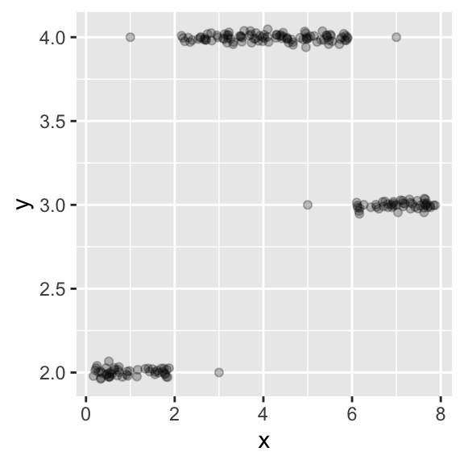

The above plot shows $\mathcal{D}= \left( \left(\mathbf{x}^{(1)}, y^{(1)}\right), \ldots, \left(\mathbf{x}^{(n)}, y^{(n)}\right)\right)$, a data set with $n = 200$ observations of a continuous target variable $y$ and a continuous, 1-dimensional feature variable $\mathbf{x}$. In the following, we aim at predicting $y$ with a machine learning model that takes $\mathbf{x}$ as input.

1. To prepare the data for classification, we categorize the target variable $y$ in 3 classes and call the transformed target variable $z$, as follows:
   $$z^{(i)} =
   \begin{cases}
   1, & y^{(i)} \in (-\infty, 2.5] \\
   2, & y^{(i)} \in (2.5, 3.5] \\
   3, & y^{(i)} \in (3.5, \infty)
   \end{cases}$$

   Now we can apply quadratic discriminant analysis (QDA):
   1. Estimate the class means $\mu_k = \mathbb{E}(\mathbf{x}|z = k)$ for each of the three classes $k \in \{1, 2, 3\}$ visually from the plot. Do not overcomplicate this, a rough estimate is sufficient here.
   2. Make a plot that visualizes the different estimated densities per class.
   3. How would your plot from ii) change if we used linear discriminant analysis (LDA) instead of QDA? Explain your answer.
   4. Why is QDA preferable over LDA for this data?
2. Given are two new observations $\mathbf{x}_{*1} = -10$ and $\mathbf{x}_{*2} = 7$. State the prediction for QDA and explain how you arrive there.

## Exercise 3: Decision Boundaries for Classification Learners

**Learning goals**

We will now visualize how well different learners classify the three-class `mlbench::mlbench.cassini` data set.

1. Generate 1000 points from `cassini` using R or import [`cassini_data.csv`](https://github.com/slds-lmu/lecture_i2ml/blob/master/exercises/data/cassini_data.csv) in Python.
2. Then, perturb the `x.2` dimension with Gaussian noise (mean 0, standard deviation 0.5), and consider the classifiers already introduced in the lecture:
   - LDA (Linear Discriminant Analysis),
   - QDA (Quadratic Discriminant Analysis), and
   - Naive Bayes.

Plot the learners’ decision boundaries. Can you spot differences in separation ability?

(Note that logistic regression cannot handle more than two classes and is therefore not listed here.)